# PennState Stat 501 Lesson 6 - MLR Model Evaluation

Author: Rick Dean

Article date: 2021-03-18

Abstract

The following notes, and R scripts are based on the online course [PennState Lesson 6 MLR Model Evaluation](https://online.stat.psu.edu/stat501/lesson/6)

```r
library(knitr)
library(kableExtra)
library(data.table)
library(RregressPkg)
library(RplotterPkg)
library(ggplot2)
library(here)

current_dir <- here::here("PennState-Stat 501 Regression Methods")
```

## 6.1 Three types of hypotheses

Research questions:

### Example 6-1: Heart attacks in rabbits

Primary research question:

> Does the mean size of the infarcted area differ among the three treatment groups – no cooling, early cooling, and late cooling – when controlling for the size of the region at risk for infarction

The regression model:

$$area = \beta_{intercept} + \beta_{nocool} + \beta_{early} + \beta_{late} + \epsilon$$

1. Read the data:

```r
data_path <- file.path(current_dir, "data/coolhearts.txt")
coolhearts_dt <- data.table::fread(data_path)
coolhearts_dt <- coolhearts_dt[, .(Infect = `Inf`, Area = Area, Early = X2, Late = X3, Group = Group)]
```

2. Estimate the OLS

```r
coolhearts_ols_lst <- RregressPkg::ols_calc(
  df = coolhearts_dt,
  formula_obj = Infect ~ Area + Early + Late
)
```

3. Show the coefficients:

```r
RplotterPkg::create_table(x = coolhearts_ols_lst$coef_df, caption = "Infect ~ Area + Early + Late")
```

Infect ~ Area + Early + Late

| Coef | Value | SE | t_value | p_Value |
| --- | --- | --- | --- | --- |
| (Intercept) | -0.13453638 | 0.10402158 | -1.293351 | 2.064588e-01 |
| Area | 0.61265498 | 0.10704994 | 5.723076 | 3.865441e-06 |
| Early | -0.24348223 | 0.06229215 | -3.908715 | 5.364536e-04 |
| Late | -0.06565569 | 0.06506824 | -1.009028 | 3.216018e-01 |

4. Prepare data frame for plotting:

```r
coolhearts_dt[, Group := fifelse(Group == 3,"Control",
                    fifelse(Group == 1,"Early",
                    fifelse(Group == 2,"Late"," ")))]
coolhearts_dt[, Fit := coolhearts_ols_lst$fitted_val]
```

5. Plot the three conditions:

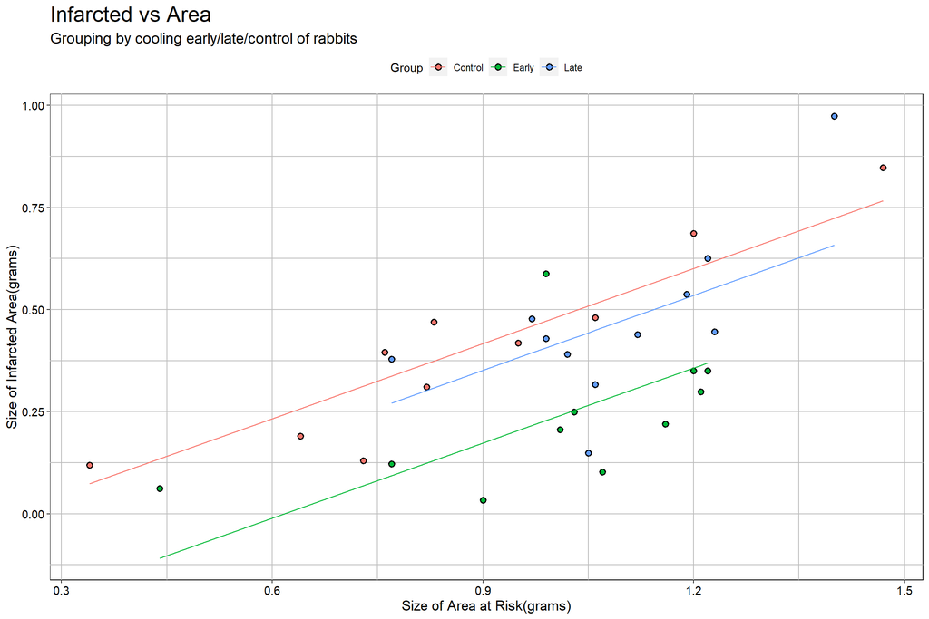

```r
RplotterPkg::create_scatter_plot(
  df = coolhearts_dt,
  aes_x = "Area",
  aes_y = "Infect",
  aes_fill = "Group",
  title = "Infarcted vs Area",
  subtitle = "Grouping by cooling early/late/control of rabbits",
  rot_y_tic_label = T,
  pts_size = 2,
  x_title = "Size of Area at Risk(grams)",
  y_title = "Size of Infarcted Area(grams)"
) + geom_line(aes(x = Area, y = Fit, color = Group))
```

## 6.2 General linear F-test

The “general linear F-test” involves three basic steps:

1. Define a larger **full model** or **unrestricted model** (one with more parameters)
2. Define a smaller **reduced model** or **restricted model** (one with fewer parameters)
3. Use the **F-statistic** to decide whether or not to reject the smaller reduced model in favor of the larger full model

The $F$-statistic is defined as follows:

$$F = \left ( \frac{SSE_{r} - SSE_{ur}}{df_{r} - df_{ur}} \right ) \div \left ( \frac{SSE_{ur}}{df_{ur}} \right )$$
Note q = $df_{r} - df_{ur}$ = the difference in the number of predictors between the full and reduced models

An alternative definition from $F$ involves the $R^2$ values from the full and reduced models – known as the **R-squared form of the F statistic**:
$$F = \frac{(R_{ur}^2 - R_{r}^2)/q}{(1 - R_{ur}^2)/df_{ur}}$$

We use the general linear $F$-statistic to decide whether or not:

1. to reject the null hypothesis $H_{0}$: the reduced model
2. in favor of the alternative hypothesis $H_{A}$: the full model

### Example 6-2: Alcohol and muscle strength data

The Hypotheses’ –

Reduced model:
$$H_{0}: y_{strength} = \beta_{intercept} + \epsilon$$

Full model:
$$H_{A}: y_{strength} = \beta_{intercept} + \beta_{alcohol} + \epsilon$$

1. Set the data:

```r
data_path <- file.path(current_dir, "data/alcoholarm.txt")
alchoholarm_dt <- data.table::fread(data_path)
```

2. Estimate the reduced and full models:

```r
# reduced_ols <- mean(alchoholarm_dt$strength)
# reduced_sse <- sum((alchoholarm_dt$strength - reduced_ols)^2)
# using only the intercept in the model
reduced_ols <- RregressPkg::ols_calc(
  df = alchoholarm_dt,
  formula_obj = strength ~ 1
)
reduced_sse <- reduced_ols$sse

full_ols <- RregressPkg::ols_calc(
  df = alchoholarm_dt,
  formula_obj = strength ~ alcohol
)
full_sse <- full_ols$sse
```

3. Create the plot data frame and display the reduced and full models:

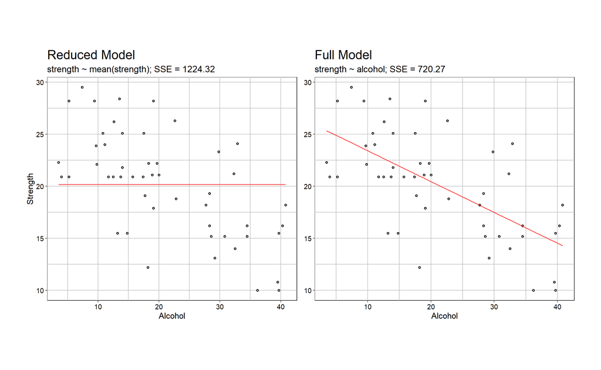

```r
plot_df <- data.frame(
  Alcohol = alchoholarm_dt$alcohol,
  Strength = alchoholarm_dt$strength,
  Strength_R = reduced_ols$fitted_val,
  Strength_F = full_ols$fitted_val
)

reduced_plot <- RplotterPkg::create_scatter_plot(
  df = plot_df,
  aes_x = "Alcohol",
  aes_y = "Strength",
  title = "Reduced Model",
  subtitle = paste0("strength ~ mean(strength); SSE = ",round(reduced_sse,digits = 2)),
  rot_y_tic_label = T
) + geom_line(aes(y = Strength_R), color="red")
#reduced_plot

full_plot <- RplotterPkg::create_scatter_plot(
  df = plot_df,
  aes_x = "Alcohol",
  aes_y = "Strength",
  title = "Full Model",
  subtitle = paste0("strength ~ alcohol; SSE = ",round(full_sse, digits = 2)),
  rot_y_tic_label = T,
  do_y_title = F
) + geom_line(aes(y = Strength_F), color="red")

layout <- list(
  plots = list(reduced_plot, full_plot),
  rows = c(1,1),
  cols = c(1,2)
)
RplotterPkg::multi_panel_grid(
  layout = layout,
  col_widths = c(6,6),
  row_heights = 6
  #title = "Reduced and Full Model of Alcohol vs Strength"
)
```

4. Estimate F from the full and reduced models: From above we have from the full *full_ols* and reduced model *reduced_ols*:

Error sum squares:

```r
SSE_ur <- full_ols$sse
SSE_r <- reduced_ols$sse
q <- full_ols$k - reduced_ols$k
df_ur <- full_ols$n - full_ols$k - 1

F_val <- ((SSE_r - SSE_ur)/q)/(SSE_ur/df_ur)
```

The $F$ value is 32.8900747

## 6.3 Sequential (or extra) sums of squares

It can be viewed in either of two ways:

1. It is the reduction in the **error sum of the squares** (SSE) when one or more predictor variables are added to the model
2. It is the increase in the **regression sum of the squares** (SSR) when one or more predictors are added to the model

Doing the exercises in this section using the IQ size data. Setting up the data:

```r
data_path <- file.path(current_dir, "data/iqsize.txt")
iqsize_dt <- data.table::fread(data_path)
```

1. $X_{Brain}$ as the only predictor:

```r
brain_ols <- RregressPkg::ols_calc(
  df = iqsize_dt,
  formula_obj = PIQ ~ Brain
)
RplotterPkg::create_table(x = brain_ols$anova_df)
```

| Source | DF | SS | MS |
| --- | --- | --- | --- |
| Regression | 1 | 2697.094 | 2697.0939 |
| Residual Error | 36 | 16197.459 | 449.9294 |
| Total | 37 | 18894.553 | NA |

SSE(Brain) = 16197 SSR(Brain) = 2697 SSTO(Brain) = 18895

2. Fit with regressors $X_{Brain}$ and $X_{Height}$

```r
brain_height_ols <- RregressPkg::ols_calc(
  df = iqsize_dt,
  formula_obj = PIQ ~ Brain + Height
)
RplotterPkg::create_table(x = brain_height_ols$anova_df)
```

| Source | DF | SS | MS |
| --- | --- | --- | --- |
| Regression | 2 | 5572.741 | 2786.3706 |
| Residual Error | 35 | 13321.811 | 380.6232 |
| Total | 37 | 18894.553 | NA |

SSE(Brain,Height) = 13322 SSR(Brain,Height) = 5573 SSTO(Brian,Height) = 18895 – the same as above

3. Sequential sum of the squares: Of adding Height where Brain is the only predictor SSR(Height|Brain)

SSR(Height|Brain) = Reduction in error sum of the squares = SSE(Brain) - SSE(Brain,Height) = 16197 - 13322 = 2875

Or

SSR(Height|Brain) = Increase in regression sum of the squares = SSR(Brain,Height) - SSR(Brain) = 5573 - 2697 = 2876

4. (MiniTab question)
5. Order matters – add the predictors in the reverse order – $X_{Height}$ then $X_{Brain}$ $X_{Height}$ as the only predictor:

```r
height_ols <- RregressPkg::ols_calc(
  df = iqsize_dt,
  formula_obj = PIQ ~ Height
)
RplotterPkg::create_table(x = height_ols$anova_df)
```

| Source | DF | SS | MS |
| --- | --- | --- | --- |
| Regression | 1 | 163.9662 | 163.9662 |
| Residual Error | 36 | 18730.5864 | 520.2941 |
| Total | 37 | 18894.5526 | NA |

SSE = 18731 SSR = 164 SSTO = 18895

Now add in the Brain to the model:

```r
height_brain_ols <- RregressPkg::ols_calc(
  df = iqsize_dt,
  formula_obj = PIQ ~ Height + Brain
)
RplotterPkg::create_table(x = height_brain_ols$anova_df)
```

| Source | DF | SS | MS |
| --- | --- | --- | --- |
| Regression | 2 | 5572.741 | 2786.3706 |
| Residual Error | 35 | 13321.811 | 380.6232 |
| Total | 37 | 18894.553 | NA |

The sequential sums of the squares: SSR(Brain|Height) = reduction in sum of squares of errors = SSE(Height) - SSE(Brain|Height) = 18731 - 13322 = 5409

Or

SSR(Brain|Height) = increase in sum of squares of regression = SSR(Brain|Height) - SSR(Height) = 5573 - 164 = 5409

6. Sequential sums of the squares for any number of predictors. Build a model in order: $X_{Brain}$, $X_{Height}$, $X_{Weight}$

Start with only $X_{Brain}$:

```r
brain_ols <- RregressPkg::ols_calc(
  df = iqsize_dt,
  formula_obj = PIQ ~ Brain
)
RplotterPkg::create_table(x = brain_ols$anova_df)
```

| Source | DF | SS | MS |
| --- | --- | --- | --- |
| Regression | 1 | 2697.094 | 2697.0939 |
| Residual Error | 36 | 16197.459 | 449.9294 |
| Total | 37 | 18894.553 | NA |

SSR(Brain) = 2697 SSE(Brain) = 16197

Add in $X_{Height}$:

```r
brain_height_ols <- RregressPkg::ols_calc(
  df = iqsize_dt,
  formula_obj = PIQ ~ Brain + Height
)
RplotterPkg::create_table(x = brain_height_ols$anova_df)
```

| Source | DF | SS | MS |
| --- | --- | --- | --- |
| Regression | 2 | 5572.741 | 2786.3706 |
| Residual Error | 35 | 13321.811 | 380.6232 |
| Total | 37 | 18894.553 | NA |

Sequential increase in regression sum of squares: SSR(Height|Brain) = 5573 - 2697 = 2876

Now add in $X_{Weight}$ to the model:

```r
brain_height_weight_ols <- RregressPkg::ols_calc(
  df = iqsize_dt,
  formula_obj = PIQ ~ Brain + Height + Weight
)
RplotterPkg::create_table(x = brain_height_weight_ols$anova_df)
```

| Source | DF | SS | MS |
| --- | --- | --- | --- |
| Regression | 3 | 5572.744 | 1857.5815 |
| Residual Error | 34 | 13321.808 | 391.8179 |
| Total | 37 | 18894.553 | NA |

Sequential increase in regression sum of squares: SSR(Weight|Brain,Height) = 5572.744 - 5572.741 = 0.003

7. The above was **one-degree-of-freedom** sequential sums of squares – adding predictors one at a time – used for testing $H_{0}: \beta_{1} = 0$ **two-degree-of-freedom** sequential sums of squares – adding two predictors at a time: Start with only $X_{Brain}$:

```r
brain_ols <- RregressPkg::ols_calc(
  df = iqsize_dt,
  formula_obj = PIQ ~ Brain
)
RplotterPkg::create_table(x = brain_ols$anova_df)
```

| Source | DF | SS | MS |
| --- | --- | --- | --- |
| Regression | 1 | 2697.094 | 2697.0939 |
| Residual Error | 36 | 16197.459 | 449.9294 |
| Total | 37 | 18894.553 | NA |

Now add in $X_{Height}$ and $X_{Weight}$:

```r
brain_height_weight_ols <- RregressPkg::ols_calc(
  df = iqsize_dt,
  formula_obj = PIQ ~ Brain + Height + Weight
)
RplotterPkg::create_table(x = brain_height_weight_ols$anova_df)
```

| Source | DF | SS | MS |
| --- | --- | --- | --- |
| Regression | 3 | 5572.744 | 1857.5815 |
| Residual Error | 34 | 13321.808 | 391.8179 |
| Total | 37 | 18894.553 | NA |

Sequential sum squares: SSR(Height,Weight|Brain) = increase in regression sum of the squares = 5573 - 2697 = 2876

## 6.4 Hypothesis tests for the slopes

Returning to the 3 hypothesis in section 6.1 above, we will test each hypothesis using *coolhearts.txt* data and the general linear $F$-statistic:
$$F = \left ( \frac{SSE_{r} - SSE_{ur}}{df_{r} - df_{ur}} \right ) \div \left ( \frac{SSE_{ur}}{df_{ur}} \right )$$

### 6.4a Set the data

Using the coolhearts data set: 1. Read the data:

```r
data_path <- file.path(current_dir, "data/coolhearts.txt")
coolhearts_dt <- data.table::fread(data_path)
coolhearts_dt <- coolhearts_dt[, .(Infect = `Inf`, Area = Area, Early = X2, Late = X3, Group = Group)]
```

### 6.4b Testing all slope parameters equal 0

$H_{0}: \beta_{Area} = \beta_{Early} = \beta_{Late} = 0$

$H_{A}:$ At least one $\beta_{j} \ne 0$ (for $j$ = Area,Early,Late)

Compute the $F$ value:

```r
F_lst <- RregressPkg::ols_F_calc(
  df = coolhearts_dt,
  ur_formula_obj = Infect ~ Area + Early + Late,
  r_formula_obj = Infect ~ 1
)
```

[output not shown]

### 6.4c Testing one slope parameter is 0

$H_{0}: \beta_{Area} = 0$

$H_{A}: \beta_{Area} \ne 0$

Compute the $F$ value:

```r
F_lst <- RregressPkg::ols_F_calc(
  df = coolhearts_dt,
  ur_formula_obj = Infect ~ Area + Early + Late,
  r_formula_obj = Infect ~ Early + Late
)
```

[output not shown]

### Testing a subset of slope parameters is 0

$H_{0}: \beta_{Early} = \beta_{Late} = 0$

$H_{A}:$ At least one $\beta_{j} \ne 0$ (for $j$ = Early, Late)

Compute the $F$ value:

```r
F_lst <- RregressPkg::ols_F_calc(
  df = coolhearts_dt,
  ur_formula_obj = Infect ~ Area + Early + Late,
  r_formula_obj = Infect ~ Area
)
```

[output not shown]